# Risk Factor Analysis

## Outcome Variable

**Outcome Variable:** haz

## Predictor Variables

**Intervention Variable:** mwtkg

**Adjustment Set:**

- arm
- W_mage
- W_fage
- meducyrs
- feducyrs
- single
- brthmon
- W_gagebrth
- W_birthwt
- W_birthlen
- vagbrth
- delta_W_mage
- delta_W_fage
- delta_meducyrs
- delta_feducyrs
- delta_single
- delta_brthmon
- delta_W_gagebrth
- delta_W_birthwt
- delta_W_birthlen
- delta_vagbrth

## Stratifying Variables

The analysis was stratified on these variable(s):

- agecat
- studyid
- country

## Data Summary

| agecat | studyid | country | mwtkg | n_cell | n |
| --- | --- | --- | --- | --- | --- |
| 6 months | LCNI-5 | MALAWI | >=58 kg | 114 | 837 |
| 6 months | LCNI-5 | MALAWI | <52 kg | 504 | 837 |
| 6 months | LCNI-5 | MALAWI | [52-58) kg | 219 | 837 |
| 6 months | MAL-ED | BANGLADESH | >=58 kg | 46 | 241 |
| 6 months | MAL-ED | BANGLADESH | <52 kg | 154 | 241 |
| 6 months | MAL-ED | BANGLADESH | [52-58) kg | 41 | 241 |
| 6 months | MAL-ED | BRAZIL | >=58 kg | 137 | 208 |
| 6 months | MAL-ED | BRAZIL | <52 kg | 37 | 208 |
| 6 months | MAL-ED | BRAZIL | [52-58) kg | 34 | 208 |
| 6 months | MAL-ED | INDIA | >=58 kg | 40 | 235 |
| 6 months | MAL-ED | INDIA | <52 kg | 146 | 235 |
| 6 months | MAL-ED | INDIA | [52-58) kg | 49 | 235 |
| 6 months | MAL-ED | NEPAL | >=58 kg | 79 | 236 |
| 6 months | MAL-ED | NEPAL | <52 kg | 75 | 236 |
| 6 months | MAL-ED | NEPAL | [52-58) kg | 82 | 236 |
| 6 months | MAL-ED | PERU | >=58 kg | 100 | 272 |
| 6 months | MAL-ED | PERU | <52 kg | 107 | 272 |
| 6 months | MAL-ED | PERU | [52-58) kg | 65 | 272 |
| 6 months | MAL-ED | SOUTH AFRICA | >=58 kg | 179 | 249 |
| 6 months | MAL-ED | SOUTH AFRICA | <52 kg | 29 | 249 |
| 6 months | MAL-ED | SOUTH AFRICA | [52-58) kg | 41 | 249 |
| 6 months | MAL-ED | TANZANIA, UNITED REPUBLIC OF | >=58 kg | 94 | 247 |
| 6 months | MAL-ED | TANZANIA, UNITED REPUBLIC OF | <52 kg | 95 | 247 |
| 6 months | MAL-ED | TANZANIA, UNITED REPUBLIC OF | [52-58) kg | 58 | 247 |
| 6 months | NIH-Birth | BANGLADESH | >=58 kg | 71 | 537 |
| 6 months | NIH-Birth | BANGLADESH | <52 kg | 385 | 537 |
| 6 months | NIH-Birth | BANGLADESH | [52-58) kg | 81 | 537 |
| 6 months | NIH-Crypto | BANGLADESH | >=58 kg | 184 | 715 |
| 6 months | NIH-Crypto | BANGLADESH | <52 kg | 383 | 715 |
| 6 months | NIH-Crypto | BANGLADESH | [52-58) kg | 148 | 715 |

[output cut: 57 more lines]

The following strata were considered:

- agecat: 24 months, studyid: LCNI-5, country: MALAWI
- agecat: 24 months, studyid: MAL-ED, country: BANGLADESH
- agecat: 24 months, studyid: MAL-ED, country: BRAZIL
- agecat: 24 months, studyid: MAL-ED, country: INDIA
- agecat: 24 months, studyid: MAL-ED, country: NEPAL
- agecat: 24 months, studyid: MAL-ED, country: PERU
- agecat: 24 months, studyid: MAL-ED, country: SOUTH AFRICA
- agecat: 24 months, studyid: MAL-ED, country: TANZANIA, UNITED REPUBLIC OF
- agecat: 24 months, studyid: NIH-Birth, country: BANGLADESH
- agecat: 24 months, studyid: NIH-Crypto, country: BANGLADESH
- agecat: 24 months, studyid: PROBIT, country: BELARUS
- agecat: 24 months, studyid: PROVIDE, country: BANGLADESH
- agecat: 24 months, studyid: TanzaniaChild2, country: TANZANIA, UNITED REPUBLIC OF
- agecat: 24 months, studyid: ZVITAMBO, country: ZIMBABWE
- agecat: 6 months, studyid: LCNI-5, country: MALAWI
- agecat: 6 months, studyid: MAL-ED, country: BANGLADESH
- agecat: 6 months, studyid: MAL-ED, country: BRAZIL
- agecat: 6 months, studyid: MAL-ED, country: INDIA
- agecat: 6 months, studyid: MAL-ED, country: NEPAL
- agecat: 6 months, studyid: MAL-ED, country: PERU
- agecat: 6 months, studyid: MAL-ED, country: SOUTH AFRICA
- agecat: 6 months, studyid: MAL-ED, country: TANZANIA, UNITED REPUBLIC OF
- agecat: 6 months, studyid: NIH-Birth, country: BANGLADESH
- agecat: 6 months, studyid: NIH-Crypto, country: BANGLADESH
- agecat: 6 months, studyid: PROBIT, country: BELARUS
- agecat: 6 months, studyid: PROVIDE, country: BANGLADESH
- agecat: 6 months, studyid: SAS-CompFeed, country: INDIA
- agecat: 6 months, studyid: TanzaniaChild2, country: TANZANIA, UNITED REPUBLIC OF
- agecat: 6 months, studyid: ZVITAMBO, country: ZIMBABWE

### Dropped Strata

Some strata were dropped due to rare outcomes:

- agecat: 24 months, studyid: TanzaniaChild2, country: TANZANIA, UNITED REPUBLIC OF

## Methods Detail

We’re interested in the causal parameters $E[Y_a]$ for all values of $a \in \mathcal{A}$. These parameters represent the mean outcome if, possibly contrary to fact, we intervened to set all units to have $A=a$. Under the randomization and positivity assumptions, these are identified by the statistical parameters $\psi_a=E_W[E_{Y|A,W}(Y|A=a,W)]$. In addition, we’re interested in the mean of $Y$, $E[Y]$ under no intervention (the observed mean). We will estimate these parameters by using SuperLearner to fit the relevant likelihood factors – $E_{Y|A,W}(Y|A=a,W)$ and $p(A=a|W)$, and then updating our likelihood fit using a joint TMLE.

For unadjusted analyses ($W=\{\}$), initial likelihoods were estimated using Lrnr_glm to estimate the simple $E(Y|A)$ and Lrnr_mean to estimate $p(A)$. For adjusted analyses, a small library containing Lrnr_glmnet, Lrnr_xgboost, and Lrnr_mean was used.

Having estimated these parameters, we will then use the delta method to estimate relative risks and attributable risks relative to a prespecified baseline level of $A$.

# Results Detail

## Results Plots

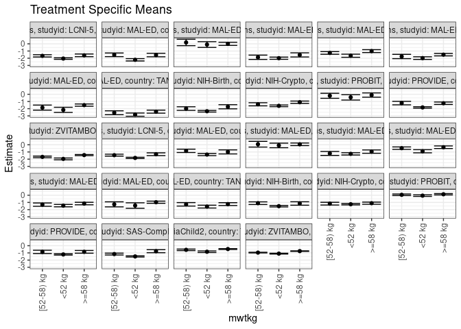

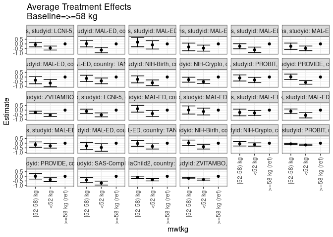

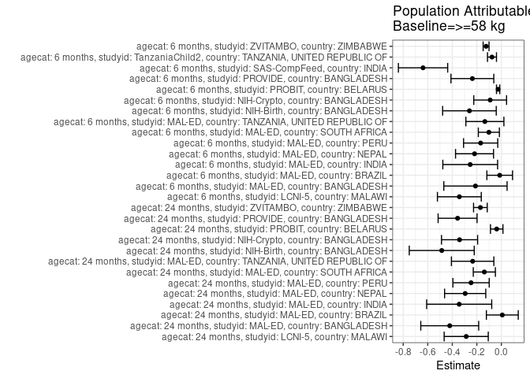

## Results Table

### Parameter: TSM

| agecat | studyid | country | intervention_level | baseline_level | estimate | ci_lower | ci_upper |
| --- | --- | --- | --- | --- | --- | --- | --- |
| 6 months | LCNI-5 | MALAWI | >=58 kg | NA | -1.3160513 | -1.5075714 | -1.1245312 |
| 6 months | LCNI-5 | MALAWI | <52 kg | NA | -1.8287331 | -1.9162576 | -1.7412087 |
| 6 months | LCNI-5 | MALAWI | [52-58) kg | NA | -1.4473167 | -1.5822323 | -1.3124011 |
| 6 months | MAL-ED | BANGLADESH | >=58 kg | NA | -0.9938120 | -1.2754744 | -0.7121496 |
| 6 months | MAL-ED | BANGLADESH | <52 kg | NA | -1.3634581 | -1.5145208 | -1.2123954 |
| 6 months | MAL-ED | BANGLADESH | [52-58) kg | NA | -0.8448742 | -1.0766379 | -0.6131105 |
| 6 months | MAL-ED | BRAZIL | >=58 kg | NA | 0.0632715 | -0.1183396 | 0.2448825 |
| 6 months | MAL-ED | BRAZIL | <52 kg | NA | -0.0904731 | -0.4086003 | 0.2276541 |
| 6 months | MAL-ED | BRAZIL | [52-58) kg | NA | 0.0753634 | -0.3193663 | 0.4700932 |
| 6 months | MAL-ED | INDIA | >=58 kg | NA | -0.9520593 | -1.1839527 | -0.7201659 |
| 6 months | MAL-ED | INDIA | <52 kg | NA | -1.2655430 | -1.4228419 | -1.1082442 |
| 6 months | MAL-ED | INDIA | [52-58) kg | NA | -1.2047067 | -1.4798794 | -0.9295340 |
| 6 months | MAL-ED | NEPAL | >=58 kg | NA | -0.3429147 | -0.5252174 | -0.1606120 |
| 6 months | MAL-ED | NEPAL | <52 kg | NA | -0.9019061 | -1.1194631 | -0.6843490 |
| 6 months | MAL-ED | NEPAL | [52-58) kg | NA | -0.4728659 | -0.6448871 | -0.3008447 |
| 6 months | MAL-ED | PERU | >=58 kg | NA | -1.1552223 | -1.3288919 | -0.9815526 |
| 6 months | MAL-ED | PERU | <52 kg | NA | -1.4439865 | -1.6121771 | -1.2757959 |
| 6 months | MAL-ED | PERU | [52-58) kg | NA | -1.3062454 | -1.5365685 | -1.0759224 |
| 6 months | MAL-ED | SOUTH AFRICA | >=58 kg | NA | -0.9708407 | -1.1218829 | -0.8197984 |
| 6 months | MAL-ED | SOUTH AFRICA | <52 kg | NA | -1.4339124 | -1.8136705 | -1.0541544 |
| 6 months | MAL-ED | SOUTH AFRICA | [52-58) kg | NA | -1.2694669 | -1.6219488 | -0.9169849 |
| 6 months | MAL-ED | TANZANIA, UNITED REPUBLIC OF | >=58 kg | NA | -1.2343637 | -1.4310292 | -1.0376982 |
| 6 months | MAL-ED | TANZANIA, UNITED REPUBLIC OF | <52 kg | NA | -1.5817121 | -1.7800131 | -1.3834111 |
| 6 months | MAL-ED | TANZANIA, UNITED REPUBLIC OF | [52-58) kg | NA | -1.2663307 | -1.5068376 | -1.0258238 |
| 6 months | NIH-Birth | BANGLADESH | >=58 kg | NA | -1.1472072 | -1.3839412 | -0.9104731 |
| 6 months | NIH-Birth | BANGLADESH | <52 kg | NA | -1.5200381 | -1.6239709 | -1.4161054 |
| 6 months | NIH-Birth | BANGLADESH | [52-58) kg | NA | -1.1064866 | -1.2913891 | -0.9215841 |
| 6 months | NIH-Crypto | BANGLADESH | >=58 kg | NA | -1.1073908 | -1.2576470 | -0.9571345 |
| 6 months | NIH-Crypto | BANGLADESH | <52 kg | NA | -1.2497892 | -1.3465557 | -1.1530227 |
| 6 months | NIH-Crypto | BANGLADESH | [52-58) kg | NA | -1.1695614 | -1.3573378 | -0.9817850 |

[output cut: 54 more lines]

### Parameter: E(Y)

| agecat | studyid | country | intervention_level | baseline_level | estimate | ci_lower | ci_upper |
| --- | --- | --- | --- | --- | --- | --- | --- |
| 6 months | LCNI-5 | MALAWI | NA | NA | -1.6584707 | -1.7281551 | -1.5887863 |
| 6 months | MAL-ED | BANGLADESH | NA | NA | -1.2049931 | -1.3222136 | -1.0877726 |
| 6 months | MAL-ED | BRAZIL | NA | NA | 0.0497516 | -0.0948051 | 0.1943083 |
| 6 months | MAL-ED | INDIA | NA | NA | -1.2059574 | -1.3243030 | -1.0876119 |
| 6 months | MAL-ED | NEPAL | NA | NA | -0.5615819 | -0.6741832 | -0.4489807 |
| 6 months | MAL-ED | PERU | NA | NA | -1.3241023 | -1.4325083 | -1.2156964 |
| 6 months | MAL-ED | SOUTH AFRICA | NA | NA | -1.0727443 | -1.2024880 | -0.9430006 |
| 6 months | MAL-ED | TANZANIA, UNITED REPUBLIC OF | NA | NA | -1.3687449 | -1.4907629 | -1.2467270 |
| 6 months | NIH-Birth | BANGLADESH | NA | NA | -1.4073821 | -1.4960598 | -1.3187043 |
| 6 months | NIH-Crypto | BANGLADESH | NA | NA | -1.1986783 | -1.2700937 | -1.1272630 |
| 6 months | PROBIT | BELARUS | NA | NA | 0.1064864 | 0.0157994 | 0.1971734 |
| 6 months | PROVIDE | BANGLADESH | NA | NA | -1.0895301 | -1.1639589 | -1.0151013 |
| 6 months | SAS-CompFeed | INDIA | NA | NA | -1.4006917 | -1.4821813 | -1.3192022 |
| 6 months | TanzaniaChild2 | TANZANIA, UNITED REPUBLIC OF | NA | NA | -0.5424765 | -0.5918460 | -0.4931071 |
| 6 months | ZVITAMBO | ZIMBABWE | NA | NA | -0.8785195 | -0.9045379 | -0.8525011 |
| 24 months | LCNI-5 | MALAWI | NA | NA | -1.8854671 | -1.9666281 | -1.8043062 |
| 24 months | MAL-ED | BANGLADESH | NA | NA | -1.9783962 | -2.1050210 | -1.8517715 |
| 24 months | MAL-ED | BRAZIL | NA | NA | 0.0059127 | -0.1637934 | 0.1756188 |
| 24 months | MAL-ED | INDIA | NA | NA | -1.8844690 | -2.0097879 | -1.7591502 |
| 24 months | MAL-ED | NEPAL | NA | NA | -1.3075877 | -1.4270718 | -1.1881037 |
| 24 months | MAL-ED | PERU | NA | NA | -1.7524710 | -1.8736426 | -1.6312994 |
| 24 months | MAL-ED | SOUTH AFRICA | NA | NA | -1.6432229 | -1.7795844 | -1.5068615 |
| 24 months | MAL-ED | TANZANIA, UNITED REPUBLIC OF | NA | NA | -2.6455607 | -2.7807256 | -2.5103959 |
| 24 months | NIH-Birth | BANGLADESH | NA | NA | -2.2190579 | -2.3217459 | -2.1163699 |
| 24 months | NIH-Crypto | BANGLADESH | NA | NA | -1.4412646 | -1.5249156 | -1.3576135 |
| 24 months | PROBIT | BELARUS | NA | NA | -0.1439152 | -0.4247957 | 0.1369654 |
| 24 months | PROVIDE | BANGLADESH | NA | NA | -1.6002600 | -1.6836163 | -1.5169036 |
| 24 months | ZVITAMBO | ZIMBABWE | NA | NA | -1.6070497 | -1.6645093 | -1.5495902 |

### Parameter: ATE

| agecat | studyid | country | intervention_level | baseline_level | estimate | ci_lower | ci_upper |
| --- | --- | --- | --- | --- | --- | --- | --- |
| 6 months | LCNI-5 | MALAWI | >=58 kg | >=58 kg | 0.0000000 | 0.0000000 | 0.0000000 |
| 6 months | LCNI-5 | MALAWI | <52 kg | >=58 kg | -0.5126818 | -0.7232692 | -0.3020945 |
| 6 months | LCNI-5 | MALAWI | [52-58) kg | >=58 kg | -0.1312654 | -0.3656686 | 0.1031378 |
| 6 months | MAL-ED | BANGLADESH | >=58 kg | >=58 kg | 0.0000000 | 0.0000000 | 0.0000000 |
| 6 months | MAL-ED | BANGLADESH | <52 kg | >=58 kg | -0.3696461 | -0.6903144 | -0.0489778 |
| 6 months | MAL-ED | BANGLADESH | [52-58) kg | >=58 kg | 0.1489378 | -0.2165735 | 0.5144492 |
| 6 months | MAL-ED | BRAZIL | >=58 kg | >=58 kg | 0.0000000 | 0.0000000 | 0.0000000 |
| 6 months | MAL-ED | BRAZIL | <52 kg | >=58 kg | -0.1537446 | -0.5207172 | 0.2132280 |
| 6 months | MAL-ED | BRAZIL | [52-58) kg | >=58 kg | 0.0120920 | -0.4243644 | 0.4485484 |
| 6 months | MAL-ED | INDIA | >=58 kg | >=58 kg | 0.0000000 | 0.0000000 | 0.0000000 |
| 6 months | MAL-ED | INDIA | <52 kg | >=58 kg | -0.3134838 | -0.5934678 | -0.0334998 |
| 6 months | MAL-ED | INDIA | [52-58) kg | >=58 kg | -0.2526474 | -0.6133583 | 0.1080635 |
| 6 months | MAL-ED | NEPAL | >=58 kg | >=58 kg | 0.0000000 | 0.0000000 | 0.0000000 |
| 6 months | MAL-ED | NEPAL | <52 kg | >=58 kg | -0.5589914 | -0.8432704 | -0.2747124 |
| 6 months | MAL-ED | NEPAL | [52-58) kg | >=58 kg | -0.1299512 | -0.3813564 | 0.1214540 |
| 6 months | MAL-ED | PERU | >=58 kg | >=58 kg | 0.0000000 | 0.0000000 | 0.0000000 |
| 6 months | MAL-ED | PERU | <52 kg | >=58 kg | -0.2887643 | -0.5293907 | -0.0481378 |
| 6 months | MAL-ED | PERU | [52-58) kg | >=58 kg | -0.1510232 | -0.4391545 | 0.1371082 |
| 6 months | MAL-ED | SOUTH AFRICA | >=58 kg | >=58 kg | 0.0000000 | 0.0000000 | 0.0000000 |
| 6 months | MAL-ED | SOUTH AFRICA | <52 kg | >=58 kg | -0.4630718 | -0.8720274 | -0.0541162 |
| 6 months | MAL-ED | SOUTH AFRICA | [52-58) kg | >=58 kg | -0.2986262 | -0.6825282 | 0.0852758 |
| 6 months | MAL-ED | TANZANIA, UNITED REPUBLIC OF | >=58 kg | >=58 kg | 0.0000000 | 0.0000000 | 0.0000000 |
| 6 months | MAL-ED | TANZANIA, UNITED REPUBLIC OF | <52 kg | >=58 kg | -0.3473484 | -0.6266510 | -0.0680457 |
| 6 months | MAL-ED | TANZANIA, UNITED REPUBLIC OF | [52-58) kg | >=58 kg | -0.0319670 | -0.3430180 | 0.2790841 |
| 6 months | NIH-Birth | BANGLADESH | >=58 kg | >=58 kg | 0.0000000 | 0.0000000 | 0.0000000 |
| 6 months | NIH-Birth | BANGLADESH | <52 kg | >=58 kg | -0.3728310 | -0.6289251 | -0.1167368 |
| 6 months | NIH-Birth | BANGLADESH | [52-58) kg | >=58 kg | 0.0407205 | -0.2578424 | 0.3392835 |
| 6 months | NIH-Crypto | BANGLADESH | >=58 kg | >=58 kg | 0.0000000 | 0.0000000 | 0.0000000 |
| 6 months | NIH-Crypto | BANGLADESH | <52 kg | >=58 kg | -0.1423985 | -0.3215777 | 0.0367808 |
| 6 months | NIH-Crypto | BANGLADESH | [52-58) kg | >=58 kg | -0.0621706 | -0.3028890 | 0.1785477 |

[output cut: 54 more lines]

### Parameter: PAR

| agecat | studyid | country | intervention_level | baseline_level | estimate | ci_lower | ci_upper |
| --- | --- | --- | --- | --- | --- | --- | --- |
| 6 months | LCNI-5 | MALAWI | >=58 kg | NA | -0.3424194 | -0.5211723 | -0.1636666 |
| 6 months | MAL-ED | BANGLADESH | >=58 kg | NA | -0.2111811 | -0.4691080 | 0.0467458 |
| 6 months | MAL-ED | BRAZIL | >=58 kg | NA | -0.0135198 | -0.1180880 | 0.0910483 |
| 6 months | MAL-ED | INDIA | >=58 kg | NA | -0.2538982 | -0.4772167 | -0.0305796 |
| 6 months | MAL-ED | NEPAL | >=58 kg | NA | -0.2186672 | -0.3734738 | -0.0638607 |
| 6 months | MAL-ED | PERU | >=58 kg | NA | -0.1688801 | -0.3082120 | -0.0295481 |
| 6 months | MAL-ED | SOUTH AFRICA | >=58 kg | NA | -0.1019037 | -0.1877228 | -0.0160845 |
| 6 months | MAL-ED | TANZANIA, UNITED REPUBLIC OF | >=58 kg | NA | -0.1343813 | -0.2893889 | 0.0206263 |
| 6 months | NIH-Birth | BANGLADESH | >=58 kg | NA | -0.2601749 | -0.4787537 | -0.0415961 |
| 6 months | NIH-Crypto | BANGLADESH | >=58 kg | NA | -0.0912876 | -0.2250310 | 0.0424559 |
| 6 months | PROBIT | BELARUS | >=58 kg | NA | -0.0264119 | -0.0397470 | -0.0130768 |
| 6 months | PROVIDE | BANGLADESH | >=58 kg | NA | -0.2362820 | -0.4108579 | -0.0617061 |
| 6 months | SAS-CompFeed | INDIA | >=58 kg | NA | -0.6385119 | -0.8393780 | -0.4376458 |
| 6 months | TanzaniaChild2 | TANZANIA, UNITED REPUBLIC OF | >=58 kg | NA | -0.0764446 | -0.1130688 | -0.0398204 |
| 6 months | ZVITAMBO | ZIMBABWE | >=58 kg | NA | -0.1245170 | -0.1484683 | -0.1005658 |
| 24 months | LCNI-5 | MALAWI | >=58 kg | NA | -0.2865163 | -0.4662614 | -0.1067712 |
| 24 months | MAL-ED | BANGLADESH | >=58 kg | NA | -0.4208894 | -0.6569762 | -0.1848026 |
| 24 months | MAL-ED | BRAZIL | >=58 kg | NA | 0.0077467 | -0.1221557 | 0.1376491 |
| 24 months | MAL-ED | INDIA | >=58 kg | NA | -0.3437147 | -0.6088934 | -0.0785360 |
| 24 months | MAL-ED | NEPAL | >=58 kg | NA | -0.2949173 | -0.4627658 | -0.1270689 |
| 24 months | MAL-ED | PERU | >=58 kg | NA | -0.2470694 | -0.3951847 | -0.0989541 |
| 24 months | MAL-ED | SOUTH AFRICA | >=58 kg | NA | -0.1387780 | -0.2289691 | -0.0485868 |
| 24 months | MAL-ED | TANZANIA, UNITED REPUBLIC OF | >=58 kg | NA | -0.2341331 | -0.4070983 | -0.0611679 |
| 24 months | NIH-Birth | BANGLADESH | >=58 kg | NA | -0.4859437 | -0.7508591 | -0.2210284 |
| 24 months | NIH-Crypto | BANGLADESH | >=58 kg | NA | -0.3406584 | -0.4877933 | -0.1935234 |
| 24 months | PROBIT | BELARUS | >=58 kg | NA | -0.0379456 | -0.0887094 | 0.0128181 |
| 24 months | PROVIDE | BANGLADESH | >=58 kg | NA | -0.3568652 | -0.5155693 | -0.1981611 |
| 24 months | ZVITAMBO | ZIMBABWE | >=58 kg | NA | -0.1708765 | -0.2266343 | -0.1151188 |